# Artificial Intelligence CA#0

### Fateme Mazdarani - 810197582

In this project we will try to solve the given maze by AI search algorithms: BFS, IDS and A* first we read the input inyo a 2D list then we run each algorithm for 3 given tests

# Modeling

initial state = Doctor in (0, 0) and Temple as it is in input

goal state = Doctor(s) in (n-1, m-1) and Temple with no potions

action = go up(x = x+1), go down(x = x-1), go right(y = y+1), go left(y = y-1) (if there is no obstacle(blocked cell or map boundries)

get potion(add it to list of tockens), get drug(new doctor in (0,0) and add drug to list of tockens)

## Input:

```python
n, m = [int(x) for x in input().split()]

temple = [ [ 0 for i in range(m) ] for j in range(n) ]

c, k = [int(x) for x in input().split()]

for i in range(0, c):
    x, y = [int(x) for x in input().split()]
    temple[x][y] = -1 #potion

for j in range(0, k):
    x, y = [int(x) for x in input().split()]
    temple[x][y] = -2 #2x drug

d = int(input())

for l in range(0, d):
    x, y = [int(x) for x in input().split()]
    temple[x][y] = k+1 #blocked
```

```
4 4
3 3
1 2
2 0
2 1
0 0
1 1
3 1
2
0 3
1 3
```

```python
initState = []
if temple[0][0] == -1:
    initState = [[(0,0)], c, [(0,0)], 0, []]
elif temple[0][0] == -2:
    initState = [[(0,0),(n-1,0)], c, [], 0, [(n-1,0)]]
else:
    initState = [[(0,0)], c, [], 0, []]
```

# BFS

in this algorithm when we select a state we will add the states we can go from it to them to the FIFO queue and we check if they are final state before adding them to the queue this algorithm is better than DFS time wise but memmory wise it is worse but it is opmimal and if there is a solution it will find it(completeness)

```python
import collections
from collections import defaultdict

def searchBFS(t, initState):
    statesSeen = 0
    path = [(0,0)]
    q = collections.deque([path])
    n = len(t)
    m = len(t[0])
    dirc = [(1,0), (-1,0), (0,1), (0, -1)]
    queue = collections.deque([initState])
    while queue:
        state = queue.popleft()
        path = q.popleft()

        if state[0]:
            x, y = state[0].pop(0)
            statesSeen += 1
            for i, j in dirc:
                if 0<=x+i<n and 0<=y+j<m and t[x+i][y+j] <=0:
                    s = [[x for x in state[0]], state[1], [x for x in state[2]], state[3], [x for x in state[4]]]
                    s[3] += 1
                    if x+i == n-1 and y+j == m-1:
                        if len(state[0]) == 0 and len(state[2]) == state[1]:
                            path.append((x+i, y+j))
                            return path, statesSeen, s[3]
                    else:
                        s[0].append((x+i, y+j))
                        if t[x+i][y+j]==-1:
                            if (x+i, y+j) not in s[2]:
                                s[2].append((x+i, y+j))
                        elif t[x+i][y+j]==-2:
                            if (x+i, y+j) not in s[4]:
                                s[4].append((x+i, y+j))
                                s[0].append((n-1, 0))
                    path.append((x+i, y+j))
                    queue.append(s)
                    q.append(path.copy())
                    path.pop()
    return False
```

## Output:

```python
temple_ = [x[:] for x in temple]
initState_ = [[x for x in initState[0]], initState[1], [x for x in initState[2]], initState[3], [x for x in initState[4]]]
p, s , l = searchBFS(temple_, initState_)
print("path: ", p, "\n total states:", s, "path length: ", l)
```

```
path:  [(0, 0), (0, 1), (2, 0), (0, 2), (2, 1), (1, 2), (2, 2), (2, 2), (3, 2), (3, 2), (3, 3), (3, 3)]
 total states: 18781 path length:  11
```

```python
%%timeit -n 3
temple_ = [x[:] for x in temple]
initState_ = [[x for x in initState[0]], initState[1], [x for x in initState[2]], initState[3], [x for x in initState[4]]]
searchBFS(temple_, initState_)
```

[output not shown]

# BFS test 1:

Average execution time = 180 ms

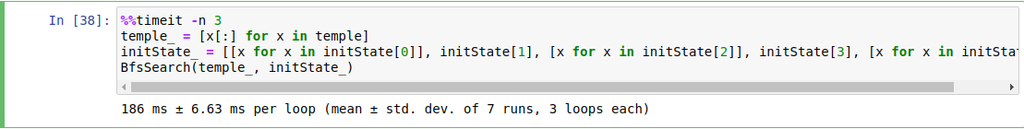

Path length = 11(states 13)

Total seen states: 27691

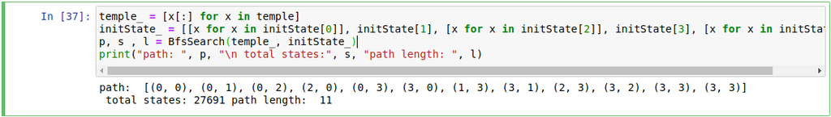

# BFS test 2:

Average execution time = 140 ms

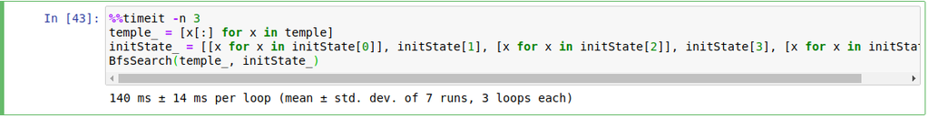

Path length = 11(state:13)

Total seen states: 18781

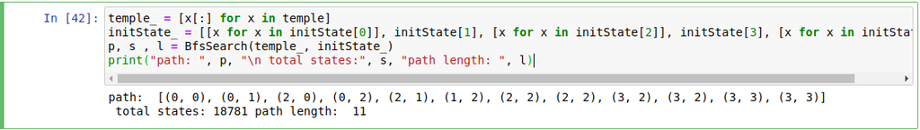

# BFS test 3:

Average execution time = 2.3 s

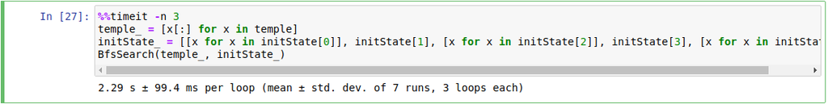

Path length = 19(state:21)

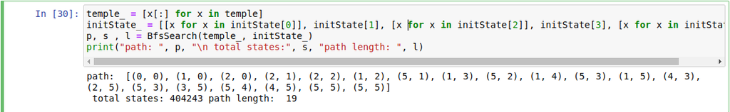

# IDS

in this algorithm when we select a state we will add the states we can go from it to the LIFO queue and we check if they are final state before adding them to the queue and then we select top of the queue and do every thing all over again this algorithm is better than DFS time wise and better than both BFS and DFS memmory wise it is also opmimal and if there is a solution it will find it(complete)

```python
def searchIDS(t, initState):
    maxDepth = 21
    statesSeen = 0
    n = len(t)
    m = len(t[0])
    dirc = [(1,0), (-1,0), (0,1), (0, -1)]
    for limit in range(1, maxDepth):
        queue = collections.deque([[[x for x in initState[0]], initState[1], [x for x in initState[2]], initState[3], [x for x in initState[4]]]])
        dq = collections.deque([0])
        path = [(0,0)]
        q = collections.deque([path])
        while queue:
            state = queue.pop()
            depth = dq.pop()
            path = q.pop()
            if depth <= limit:
                if state[0]:
                    x, y = state[0].pop(0)
                    statesSeen += 1
                    for i, j in dirc:
                        if 0<=x+i<n and 0<=y+j<m and t[x+i][y+j] <=0:
                            s = [[x for x in state[0]], state[1], [x for x in state[2]], state[3], [x for x in state[4]]]
                            s[3] += 1
                            if x+i == n-1 and y+j == m-1:
                                if len(state[0]) == 0 and len(state[2]) == state[1]:
                                    path.append((x+i, y+j))
                                    return path, statesSeen, s[3]
                            else:
                                s[0].append((x+i, y+j))
                                if t[x+i][y+j]==-1:
                                    if (x+i, y+j) not in s[2]:
                                        s[2].append((x+i, y+j))
                                elif t[x+i][y+j]==-2:
                                    if (x+i, y+j) not in s[4]:
                                        s[4].append((x+i, y+j))
                                        s[0].append((n-1, 0))
                            path.append((x+i, y+j))

                            queue.append(s)
                            dq.append(depth+1)
                            q.append(path.copy())

                            path.pop()
    return False
```

## Output:

```python
temple_ = [x[:] for x in temple]
initState_ = [[x for x in initState[0]], initState[1], [x for x in initState[2]], initState[3], [x for x in initState[4]]]
p, s , l = searchIDS(temple_, initState_)
print("path: ", p, "\n total states:", s, "path length: ", l)
```

```
path:  [(0, 0), (1, 0), (2, 0), (2, 1), (2, 2), (1, 2), (5, 1), (1, 3), (5, 2), (1, 4), (5, 3), (1, 5), (4, 3), (2, 5), (4, 4), (3, 5), (4, 5), (4, 5), (5, 5), (5, 5)]
 total states: 10656442 path length:  19
```

```python
%%timeit -n 1
temple_ = [x[:] for x in temple]
initState_ = [[x for x in initState[0]], initState[1], [x for x in initState[2]], initState[3], [x for x in initState[4]]]
searchIDS(temple_, initState_)
```

```
*
*
*
*
*
*
*
1min 11s ± 2.1 s per loop (mean ± std. dev. of 7 runs, 1 loop each)
```

## IDS test 1:

Average execution time = 137 ms

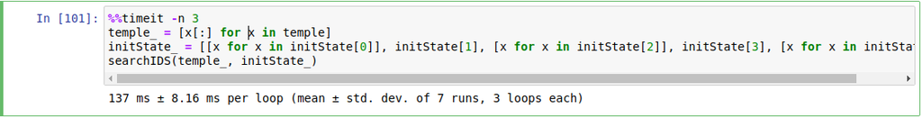

Path length = 11(states 13)

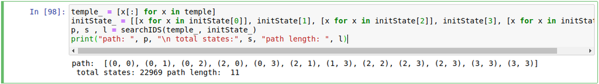

## IDS test 2:

Average execution time = 122 ms

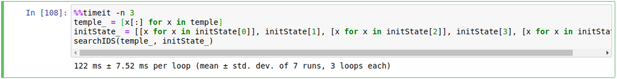

Path length = 11(states 13)

Total seen states: 18909

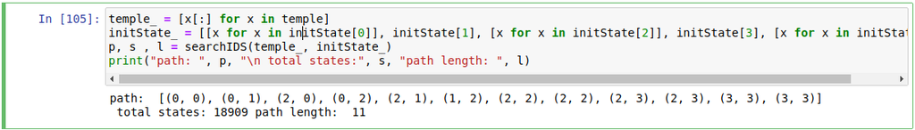

## IDS test 3:

Average execution time = 1min 11s

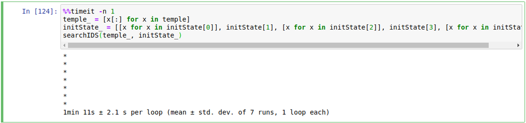

Path length = 19(states 21)

Total seen states: 10656442

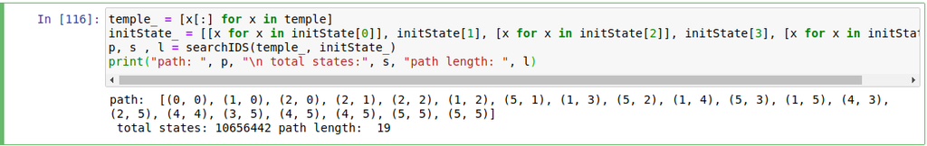

# A* search

### Heuristic (h) = manhattan distance

```python
def h(loc, m, n):
    alfa = 1
    #alfa = 1.2
    #alfa = 5
    manhattanDistance = 0
    for x, y in loc:
        manhattanDistance += (n - 1 - x) + (m - 1 - y)
    return manhattanDistance*alfa
```

```python
import heapq

def searchAstar(t, initState):
    n = len(t)
    m = len(t[0])

    statesSeen = 0
    stateList = [(h([(0,0)],m,n), initState, [(0,0)])]

    dirc = [(1,0), (-1,0), (0,1), (0, -1)]
    while stateList:
        heapq.heapify(stateList)
        curr = heapq.heappop(stateList)
        state = curr[1]
        path = curr[2]
        f = curr[0]

        if state[0]:
            x, y = state[0].pop(0)
            statesSeen += 1
            for i, j in dirc:
                if 0<=x+i<n and 0<=y+j<m and t[x+i][y+j] <=0:
                    s = [[x for x in state[0]], state[1], [x for x in state[2]], state[3], [x for x in state[4]]]
                    s[3] += 1
                    if x+i == n-1 and y+j == m-1:
                        if len(state[0]) == 0 and len(state[2]) == state[1]:
                            path.append((x+i, y+j))
                            return path, statesSeen, s[3]
                    else:
                        s[0].append((x+i, y+j))
                        if t[x+i][y+j]==-1:
                            if (x+i, y+j) not in s[2]:
                                s[2].append((x+i, y+j))
                        elif t[x+i][y+j]==-2:
                            if (x+i, y+j) not in s[4]:
                                s[4].append((x+i, y+j))
                                s[0].append((n-1, 0))
                    path.append((x+i, y+j))

                    child = (s[3]+h(s[0],m,n), [[x for x in s[0]], s[1], [x for x in s[2]], s[3], [x for x in s[4]]], path.copy())
                    heapq.heappush(stateList, child)

                    path.pop()
    return False
```

## output:

```python
%%time
temple_ = [x[:] for x in temple]
initState_ = [[x for x in initState[0]], initState[1], [x for x in initState[2]], initState[3], [x for x in initState[4]]]
p, s , l = searchAstar(temple_, initState_)
print("path: ", p, "\n total states:", s, "path length: ", l)
```

```
path:  [(0, 0), (0, 1), (2, 0), (0, 2), (2, 1), (1, 2), (2, 2), (2, 2), (2, 3), (2, 3), (3, 3), (3, 3)]
 total states: 12 path length:  11
CPU times: user 2.4 ms, sys: 97 µs, total: 2.5 ms
Wall time: 2.01 ms
```

```python
%%timeit -n 1
temple_ = [x[:] for x in temple]
initState_ = [[x for x in initState[0]], initState[1], [x for x in initState[2]], initState[3], [x for x in initState[4]]]
searchAstar(temple_, initState_)
```

```
126 µs ± 14.7 µs per loop (mean ± std. dev. of 7 runs, 1 loop each)
```

## A* test 1:

Average execution time = 2s

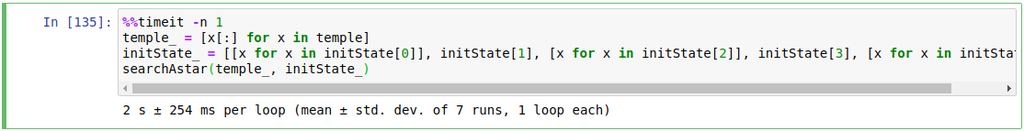

Path length = 11(states 13)

[figure not shown]

## A* test 2:

Average execution time = 671 µs

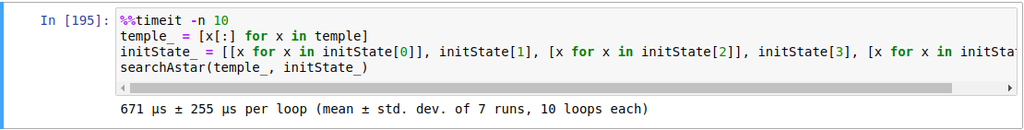

Path length = 11(states 13)

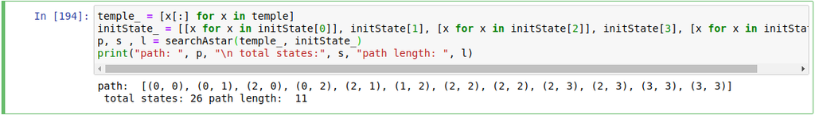